# Project Linear Model

10/1/2023

# Study 2: Communication Science Students

You can continue with the data file we created at the end of the first three steps. Please note that there are not that many units (respondents/ students) in this data set. Ideally, we would like to have more data before we attempt to analyze multivariate models. You can choose to formulate your own research question and analyze that, or you can continue with the research question formulated here.

Research question: We want to explain why some students are more satisfied with the Communication Science program than others. We expect that students who experience a high amount of study related stress will be less satisfied. We also think that involvement in the Communication Science community, in the form of participation in Communiqué events, will increase satisfaction with the program.

Note: The variable ‘participation in Communiqué events’ is measured on an ordinal scale and therefore not ideal. I especially recommend being careful when using this type of variables (ordinal, 5 or less points on the scale, measured with 1 item only) as a dependent variable as the variability might be low.

```r
# import require library
library(tidyverse)
library(psych)
library(broom)
library(modelr)
library(janitor)
library(CTT)

# load the clean dataset
dat <- read.csv("clean_data.csv")

# check the summary of the data
dat %>%
    glimpse()
```

```
## Rows: 137
## Columns: 32
## $ Consent                <int> 1, 1, 1, 1, 1, 1, 1, 1, 1, 1, 1, 1, 1, 1, 1, 1,…
## $ SM.use                 <int> 1, 1, 1, 1, 1, 1, 1, 1, 1, 1, 1, 1, 1, 1, 1, 1,…
## $ Most.used.SM           <int> 7, 1, 1, 1, 1, 2, 9, 9, 9, 9, 1, 7, 1, 2, 3, 9,…
## $ Time.spent.SM          <int> 3, 3, 2, 2, 2, 2, 1, 2, 2, 2, 2, 3, 3, 2, 2, 3,…
## $ SM.usage_1             <int> 4, 1, 2, 4, 4, 3, 3, 2, 5, 4, 2, 4, 4, 5, 5, 5,…
## $ SM.usage_2             <int> 2, 3, 2, 4, 1, 3, 3, 1, 2, 3, 2, 2, 2, 2, 4, 4,…
## $ SM.usage_3             <int> 1, 2, 1, 4, 2, 4, 2, 3, 4, 4, 3, 3, 2, 1, 4, 4,…
## $ SM.usage_4             <int> 2, 3, 4, 4, 4, 2, 2, 4, 2, 3, 4, 3, 3, 4, 5, 5,…
## $ SM.usage_5             <int> 1, 2, 4, 5, 4, 4, 2, 2, 3, 2, 1, 4, 3, 5, 4, 4,…
## $ SM.usage_6             <int> 2, 2, 1, 2, 4, 1, 4, 1, 4, 2, 2, 2, 2, 2, 3, 4,…
## $ Cyberbyllying.exp_1    <int> 1, 1, 3, 4, 1, 1, 4, 2, 1, 1, 1, 1, 2, 4, 2, 1,…
## $ Cyberbyllying.exp_2    <int> 2, 1, 3, 2, 1, 2, 5, 1, 1, 1, 1, 4, 5, 3, 3, 1,…
## $ Cyberbyllying.exp_3    <int> 1, 1, 2, 2, 1, 2, 5, 2, 1, 1, 1, 1, 4, 5, 1, 1,…
```

[output cut: 19 more lines]

```r
#omit the data which still contain NA
dat <- dat %>% na.omit()
```

- SMUsage scale - remove item 1,5
- Cyberbullying experience - not remove any item
- Social Isolation scale - not removing any item

```r
dat <- dat %>%
    mutate(
        SMUsage = (SM.usage_2 + SM.usage_3 + SM.usage_4 + SM.usage_6) / 4,
        SocialIsolation = (COVID.19.Scale_1 + COVID.19.Scale_2
            + COVID.19.Scale_3 + COVID.19.Scale_4 + COVID.19.Scale_5
            + COVID.19.Scale_6 + COVID.19.Scale_7) / 7,
        CyberbullyingExp = (Cyberbyllying.exp_1 + Cyberbyllying.exp_2
            + Cyberbyllying.exp_3 + Cyberbyllying.exp_4 + Cyberbyllying.exp_5
            + Cyberbyllying.exp_6) / 6,
        MentalHealth = (Cyberbullying.health_1 + Cyberbullying.health_2
            + Cyberbullying.health_3 + Cyberbullying.health_4
            + Cyberbullying.health_5 + Cyberbullying.health_6
            + Cyberbullying.health_7) / 7
    )
```

5. Describe your variables using relevant measures of center, spread, and range. Describe relations between variables. Include graphical representations of your data.

*We start with descriptive analyses using numbers.*

```r
dat %>%
    select(SMUsage, SocialIsolation, CyberbullyingExp, MentalHealth) %>%
    map(~ c(Mean = mean(.), Sd = sd(.), Range = range(.)))
```

```
## $SMUsage
##      Mean        Sd    Range1    Range2
## 2.7317518 0.8599734 1.0000000 4.7500000
##
## $SocialIsolation
##      Mean        Sd    Range1    Range2
## 3.1459854 0.7548298 1.1428571 5.0000000
##
## $CyberbullyingExp
##     Mean       Sd   Range1   Range2
## 2.761557 1.355182 1.000000 5.000000
##
## $MentalHealth
##      Mean        Sd    Range1    Range2
## 2.9457769 0.7989961 1.0000000 4.4285714
```

```r
dat %>%
    select(SMUsage, SocialIsolation, CyberbullyingExp, MentalHealth) %>%
    cor()
```

```
##                    SMUsage SocialIsolation CyberbullyingExp MentalHealth
## SMUsage          1.0000000      0.46005853       0.14003758    0.2951248
## SocialIsolation  0.4600585      1.00000000       0.03564821    0.3486201
## CyberbullyingExp 0.1400376      0.03564821       1.00000000    0.1821552
## MentalHealth     0.2951248      0.34862010       0.18215520    1.0000000
```

*So we can seperate these variables into 2 models as followed:*

- The effect of Social Isolation and the effect of cyberbullying mental health on Social Media usage
- The effect of Social Media usage on Cyberbullying Experience

**Model 1: The effect of Social Isolation and the effect of cyberbullying mental health on Social Media usage**

*We first do descriptive analyses using graphs. We can look at the relation between independent variables and the dependent variable in a scatter plot to see if the relationships are indeed linear and we can use a linear model to describe them.*

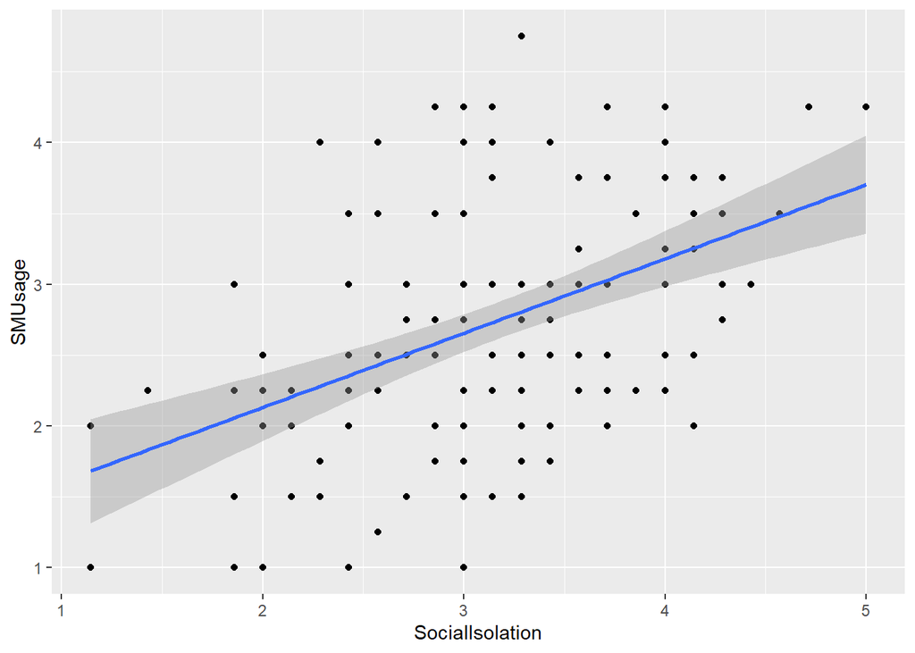

```r
dat %>%
  ggplot(aes(x = SocialIsolation, y = SMUsage)) +
  geom_point() + geom_smooth(method = "lm")
```

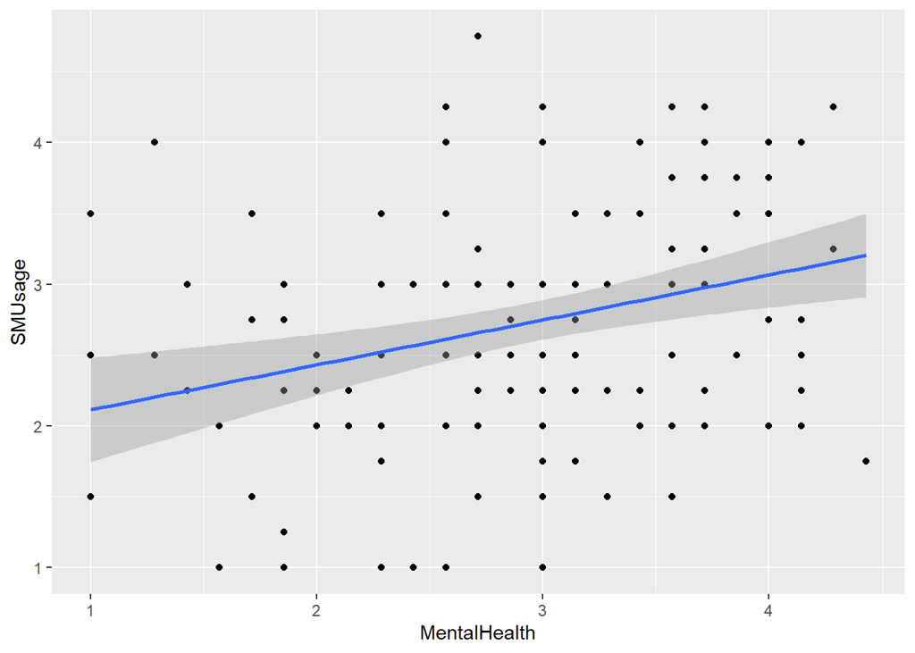

```r
dat %>%
  ggplot(aes(x = MentalHealth, y = SMUsage)) +
  geom_point() + geom_smooth(method = "lm")
```

*As we can see, there is a linear pattern in the scatter plot between SocialIsolation and SMUsage, however, there is no clear pattern (linear or curvilinear) in the second scatter plot. So we can expect that the first independent variables (Social Isolation) affected linearly to the dependent variables, and the second independent variables (MentalHealth) may not affect much to SMUsage, the relation could not fit.*

**Linear Equation and Null hypotheses**

$SocialMediaUsage_{i} = \beta_{0} + \beta_{1} \times SocialIsolation_{i} + \beta_{2} \times CyberbullyingMentalHealth_{i} + e_{i}$

$H_{01}:$ There is no effect of Social Isolation in COVID19 on Social Media Usage when we control for Cyberbullying Mental Health.

$H_{01}: \beta_{1} = 0$

$H_{02}:$ There is no effect of Cyberbullying Mental Health on Social Media Usage when we control for Social Isolation in COVID19

$H_{02}: \beta_{2} = 0$

*Give the estimated linear equation and test the hypotheses.*

```r
#We first run the regression analysis

model_1 <- dat %>%
  lm(SMUsage ~ SocialIsolation + MentalHealth, data=.)

#We then ask to see the results
model_1 %>% summary()
```

```
##
## Call:
## lm(formula = SMUsage ~ SocialIsolation + MentalHealth, data = .)
##
## Residuals:
##      Min       1Q   Median       3Q      Max
## -1.48441 -0.54100 -0.04197  0.44861  1.99174
##
## Coefficients:
##                 Estimate Std. Error t value Pr(>|t|)
## (Intercept)      0.78815    0.31917   2.469   0.0148 *
## SocialIsolation  0.46322    0.09201   5.035 1.51e-06 ***
## MentalHealth     0.16509    0.08692   1.899   0.0597 .
## ---
## Signif. codes:  0 '***' 0.001 '**' 0.01 '*' 0.05 '.' 0.1 ' ' 1
##
## Residual standard error: 0.7591 on 134 degrees of freedom
## Multiple R-squared:  0.2323, Adjusted R-squared:  0.2209
## F-statistic: 20.28 on 2 and 134 DF,  p-value: 2.028e-08
```

```r
model_1 %>% confint()
```

```
##                       2.5 %    97.5 %
## (Intercept)      0.15688799 1.4194214
## SocialIsolation  0.28125243 0.6451923
## MentalHealth    -0.00682524 0.3369971
```

```r
# a tidy table is sometimes easier to read than the summary
model_1 %>% tidy()
```

```
## # A tibble: 3 × 5
##   term            estimate std.error statistic    p.value
##   <chr>              <dbl>     <dbl>     <dbl>      <dbl>
## 1 (Intercept)        0.788    0.319       2.47 0.0148
## 2 SocialIsolation    0.463    0.0920      5.03 0.00000151
## 3 MentalHealth       0.165    0.0869      1.90 0.0597
```

We have the final model:

$SMUsage_{i} = 0.788 + 0.463 \times SocialISolation_{i} + 0.165 \times MentalHealth_{i}+ e_{i}$

*The effects of SocialIsolation and MentalHealth on Social Media Usage are in the expected directions (more social isolation during COVID19 leads to more usage of social media, and more mental health vulnerability caused by cyberbullying also leads to more usage of social media) but the effects in the latter are quite small. We have to ask ourselves first if these effects are substantially meaningful or significant. A 1 point increase in social isolation would lead to a 0.463 increase in usage of social media, which is quite significant, while the increase of mental health is on the other hands, non significant.*

*The researcher was also interested in the explanatory power of the model. R-squared for this model is 23%. which means this model explains some differences in social media usage between people in this sample, due to the effect of Social Isolation and Mental health When we adjust for possible overfitting, we arrive at an adjusted R-squared around 22%.*

**Model 2: The effect of Social Media usage on Cyberbullying Experience**

*We first do descriptive analyses using graphs. We can look at the relation between independent variables and the dependent variable in a scatter plot to see if the relationships are indeed linear and we can use a linear model to describe them.*

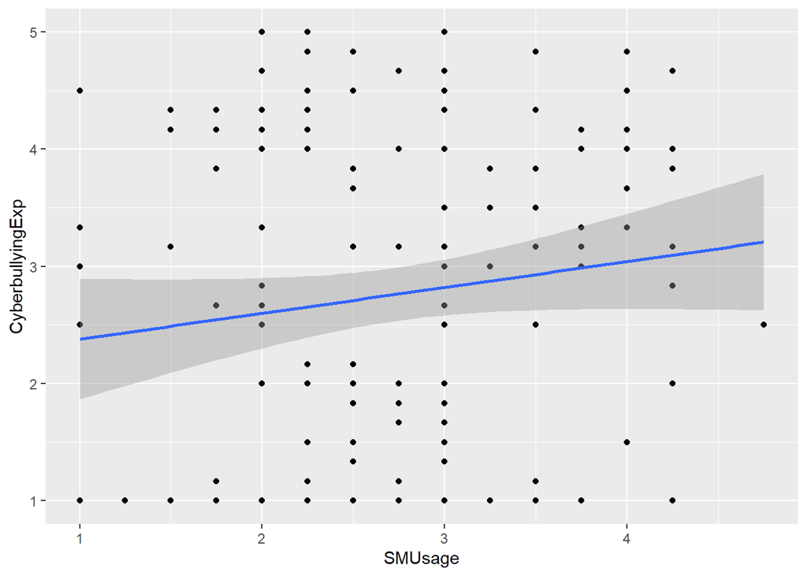

```r
dat %>%
  ggplot(aes(x = SMUsage, y = CyberbullyingExp)) +
  geom_point() + geom_smooth(method = "lm")
```

*There is no clear pattern (linear or curvilinear) in this scatter plot. So we can expect that the independent variables not affect linearly to the dependent variables, and the relation could not fit.*

**Linear Equation and Null hypotheses**

$CyberbullyingExperience_{i} = \beta_{0} + \beta_{1} \times SocialMediaUsage_{i} + e_{i}$

$H_{0}:$ There is no effect of Social Media usage on the Cyberbullying experience

$H_{0}: \beta_{1} = 0$

*Give the estimated linear equation and test the hypotheses.*

```r
#We first run the regression analysis

model_2 <- dat %>%
  lm(CyberbullyingExp ~ SMUsage, data=.)

#We then ask to see the results
model_2 %>% summary()
```

```
##
## Call:
## lm(formula = CyberbullyingExp ~ SMUsage, data = .)
##
## Residuals:
##     Min      1Q  Median      3Q     Max
## -2.0966 -1.3782  0.1218  1.1804  2.3999
##
## Coefficients:
##             Estimate Std. Error t value Pr(>|t|)
## (Intercept)   2.1587     0.3845   5.615 1.08e-07 ***
## SMUsage       0.2207     0.1343   1.643    0.103
## ---
## Signif. codes:  0 '***' 0.001 '**' 0.01 '*' 0.05 '.' 0.1 ' ' 1
##
## Residual standard error: 1.347 on 135 degrees of freedom
## Multiple R-squared:  0.01961,    Adjusted R-squared:  0.01235
## F-statistic:   2.7 on 1 and 135 DF,  p-value: 0.1027
```

```r
model_2 %>% confint()
```

```
##                   2.5 %    97.5 %
## (Intercept)  1.39835886 2.9190857
## SMUsage     -0.04490806 0.4862621
```

$CyberbullyingExp_{i} = 2.159 + 0.221 \times SMUsage_{i} + e_{i}$

```r
# a tidy table is sometimes easier to read than the summary
model_2 %>% tidy()
```

```
## # A tibble: 2 × 5
##   term        estimate std.error statistic     p.value
##   <chr>          <dbl>     <dbl>     <dbl>       <dbl>
## 1 (Intercept)    2.16      0.384      5.61 0.000000108
## 2 SMUsage        0.221     0.134      1.64 0.103
```

*The effects of social media usage is in the expected directions (more usage of social media leads to more experience of cyberbullying) but the effects is very small. We have to ask ourselves first if these small effects are substantially meaningful or significant. A 1 point increase in social media usage would lead to a 0.221 increase in cyberbullying experience. That is not so small but not a lot on the 5 point scale of cyberbullying experience.*

*Then we test the hypothesis.* *The t-value for the effect of social media usage on cyberbullying experience is 1.643 and the p-value is .103. This is higher than the alpha of .05, so we do not reject the null hypothesis that there is no effect of social media usage on the cyberbullying experience.*

*The researcher was also interested in the explanatory power of the model and R-squared for this model is 1.961%. This means that this model explains almost none of the difference in experience of cyberbullying between people in this sample. When we adjust for possible overfitting, we arrive at an adjusted R-squared is 1.235%*